# Behavioral Analysis Posner+SSVEP paradigm

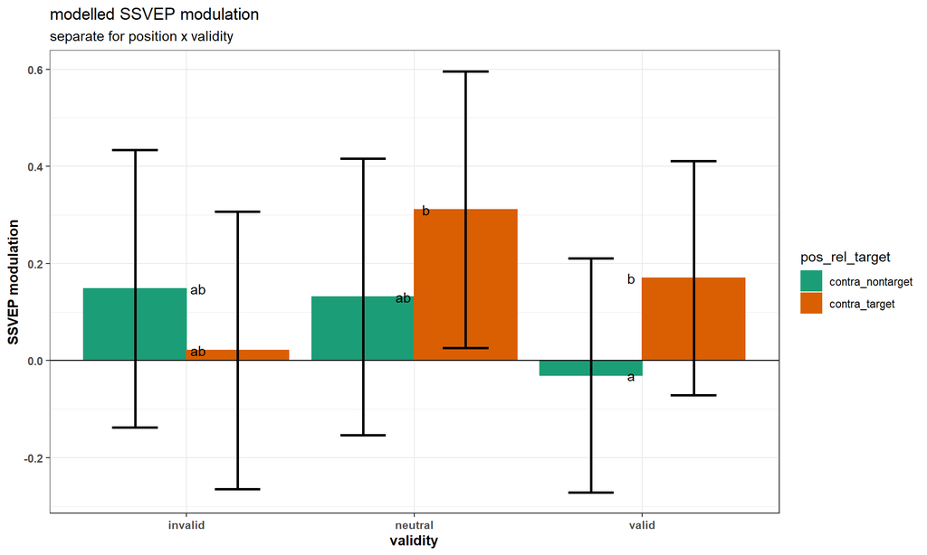

```r
CLD_obj = cld(anova_lsmeans_c,
          alpha=0.05,
          Letters=letters,      ### Use lower-case letters for .group
          adjust="holm")
CLD_obj$.group=gsub(" ", "", CLD_obj$.group)

ggplot(CLD_obj, aes(x = cue_validity_label, y = lsmean, color = pos_rel_target, fill = pos_rel_target, label = .group)) +
  stat_summary(fun.data = mean_se, geom = "bar", position = "dodge") +
  geom_hline(yintercept=0, show.legend = FALSE) +
  geom_errorbar(aes(ymin = asymp.LCL, ymax = asymp.UCL), width=.4, size=.9, position = position_dodge(0.9),color = "black") +
  theme_bw() +
  theme(axis.title = element_text(face = "bold"), axis.text = element_text(face = "bold"),plot.caption = element_text(hjust = 0)) +
  ylab("SSVEP modulation") +
  ggtitle("modelled SSVEP modulation",
           subtitle="separate for position x validity") +
  scale_x_discrete("validity") +
  # labs(caption  = paste0("\nMeans sharing a letter are ",
  #                        "not significantly different.",
  #                        "(holm corrected comparisons)."), hjust=0.5) +
 geom_text(nudge_x = c(-0.05, 0.05), color   = "black") +
  scale_fill_brewer(palette = "Dark2")+
  scale_color_brewer(palette = "Dark2")
```

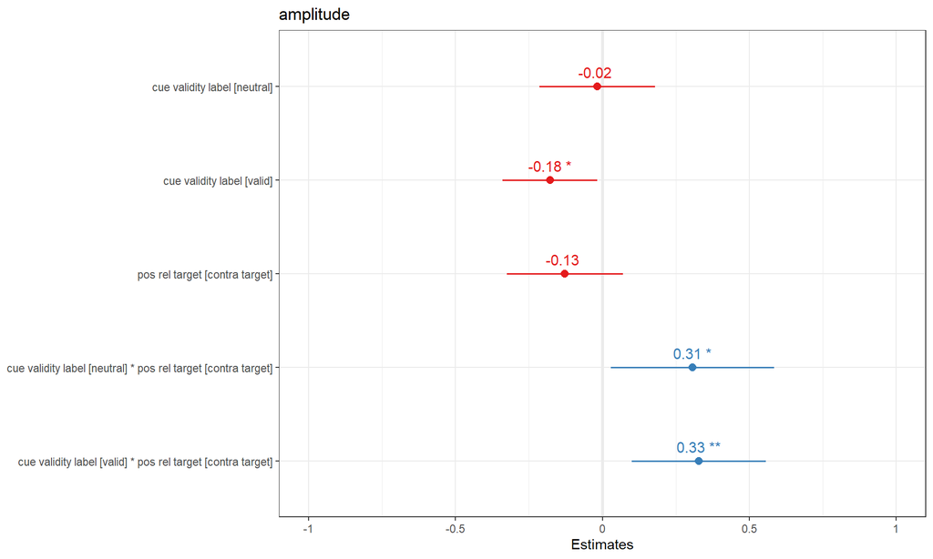

```r
plot_model(model2test, bpe.style = "dot",show.values = TRUE)
```

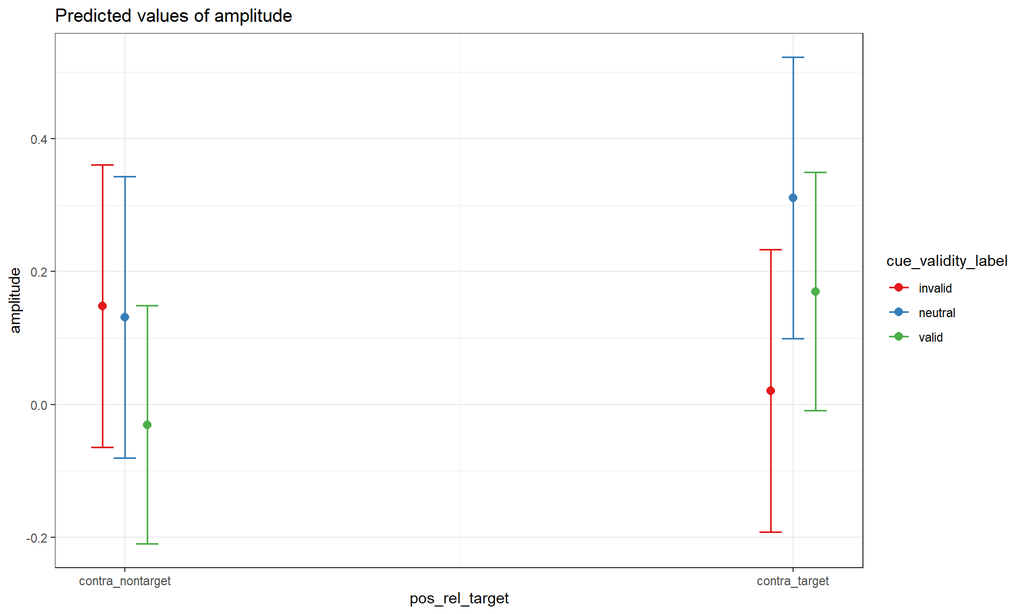

```r
plot_model(model2test, type = "pred", terms = c("pos_rel_target","cue_validity_label"))
```

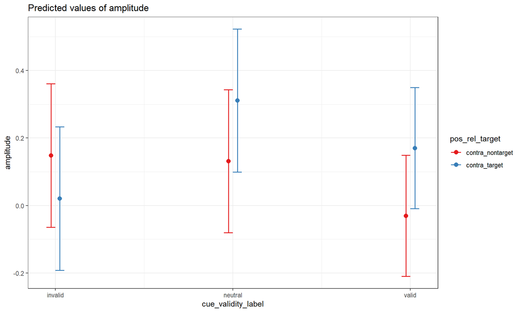

```r
plot_model(model2test, type = "pred", terms = c("cue_validity_label","pos_rel_target"))
```

### linear mixed models visual alpha II

1. **estimating model**

linear mixed model of standard effects based on single trial data

testing **visual alpha ~ Validity * Stimulus + ( 1 | subjects)**

visual Alpha | fixed effects | stepwise elimination

|  | eliminated factor | Eliminated | Sum Sq | Mean Sq | NumDF | DenDF | F value | Pr(>F) |
| --- | --- | --- | --- | --- | --- | --- | --- | --- |
| cue_validity_label:pos_rel_target | cue_validity_label:pos_rel_target | 0 | 269.39 | 134.695 | 2 | 20622.9 | 17.794 | < .001 |

2. model description of best model
   - Best model is lmerTest::lmer, amplitude ~ cue_validity_label * pos_rel_target + (1 | subject), lmer_model_data, TRUE

```r
model2test = best_model

## validity
anova_lsmeans_c <- lsmeans(model2test, c("cue_validity_label"))
```

```
## Note: D.f. calculations have been disabled because the number of observations exceeds 3000.
## To enable adjustments, add the argument 'pbkrtest.limit = 20656' (or larger)
## [or, globally, 'set emm_options(pbkrtest.limit = 20656)' or larger];
## but be warned that this may result in large computation time and memory use.
```

```
## Note: D.f. calculations have been disabled because the number of observations exceeds 3000.
## To enable adjustments, add the argument 'lmerTest.limit = 20656' (or larger)
## [or, globally, 'set emm_options(lmerTest.limit = 20656)' or larger];
## but be warned that this may result in large computation time and memory use.
```

```
## NOTE: Results may be misleading due to involvement in interactions
```

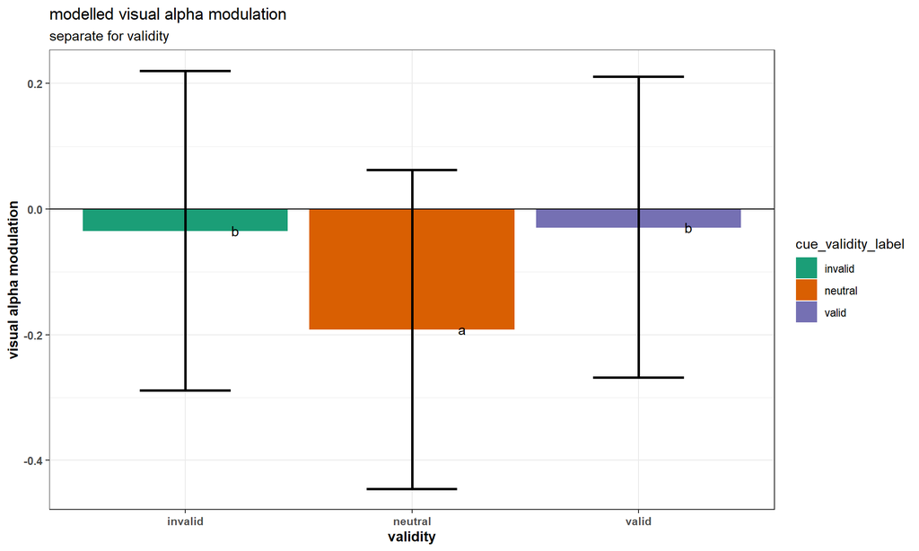

```r
CLD_obj = cld(anova_lsmeans_c,
          alpha=0.05,
          Letters=letters,      ### Use lower-case letters for .group
          adjust="holm")
CLD_obj$.group=gsub(" ", "", CLD_obj$.group)

ggplot(CLD_obj, aes(x = cue_validity_label , y = lsmean, color = cue_validity_label , fill = cue_validity_label , label = .group)) +
  stat_summary(fun.data = mean_se, geom = "bar", position = "dodge") +
  geom_hline(yintercept=0, show.legend = FALSE) +
  geom_errorbar(aes(ymin = asymp.LCL, ymax = asymp.UCL), width=.4, size=.9, position = position_dodge(0.4),color = "black") +
  theme_bw() +
  theme(axis.title = element_text(face = "bold"), axis.text = element_text(face = "bold"),plot.caption = element_text(hjust = 0)) +
  ylab("visual alpha modulation") +
  ggtitle("modelled visual alpha modulation",
           subtitle="separate for validity") +
  scale_x_discrete("validity") +
  # ggplot2::labs(caption  = paste0("\nMeans sharing a letter are ",
  #                        "not significantly different.",
  #                        "(holm corrected comparisons).")), hjust=0.5) +
  geom_text(nudge_x = c(+0.22), color   = "black") +
  scale_fill_brewer(palette = "Dark2")+
  scale_color_brewer(palette = "Dark2")
```

```r
## position
anova_lsmeans_c <- lsmeans(model2test, c("pos_rel_target"))
```

```
## Note: D.f. calculations have been disabled because the number of observations exceeds 3000.
## To enable adjustments, add the argument 'pbkrtest.limit = 20656' (or larger)
## [or, globally, 'set emm_options(pbkrtest.limit = 20656)' or larger];
## but be warned that this may result in large computation time and memory use.
```

```
## Note: D.f. calculations have been disabled because the number of observations exceeds 3000.
## To enable adjustments, add the argument 'lmerTest.limit = 20656' (or larger)
## [or, globally, 'set emm_options(lmerTest.limit = 20656)' or larger];
## but be warned that this may result in large computation time and memory use.
```

```
## NOTE: Results may be misleading due to involvement in interactions
```

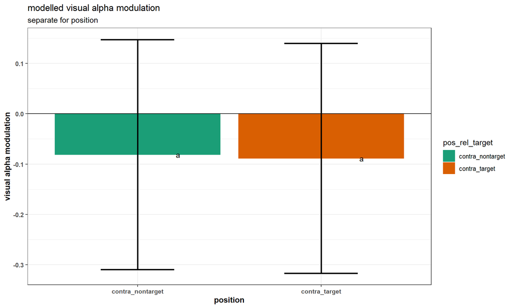

```r
CLD_obj = cld(anova_lsmeans_c,
          alpha=0.05,
          Letters=letters,      ### Use lower-case letters for .group
          adjust="holm")
CLD_obj$.group=gsub(" ", "", CLD_obj$.group)

ggplot(CLD_obj, aes(x = pos_rel_target, y = lsmean, color = pos_rel_target, fill = pos_rel_target, label = .group)) +
  stat_summary(fun.data = mean_se, geom = "bar", position = "dodge") +
  geom_hline(yintercept=0, show.legend = FALSE) +
  geom_errorbar(aes(ymin = asymp.LCL, ymax = asymp.UCL), width=.4, size=.9, position = position_dodge(0.4),color = "black") +
  theme_bw() +
  theme(axis.title = element_text(face = "bold"), axis.text = element_text(face = "bold"),plot.caption = element_text(hjust = 0)) +
  ylab("visual alpha modulation") +
  ggtitle("modelled visual alpha modulation",
           subtitle="separate for position") +
  scale_x_discrete("position") +
  # labs(caption  = paste0("\nMeans sharing a letter are ",
  #                        "not significantly different.",
  #                        "(holm corrected comparisons)."), hjust=0.5) +
  geom_text(nudge_x = c(+0.22), color   = "black") +
  scale_fill_brewer(palette = "Dark2")+
  scale_color_brewer(palette = "Dark2")
```

```r
## Validiaet X Seite
anova_lsmeans_c <- lsmeans(model2test, c("pos_rel_target","cue_validity_label"))
```

```
## Note: D.f. calculations have been disabled because the number of observations exceeds 3000.
## To enable adjustments, add the argument 'pbkrtest.limit = 20656' (or larger)
## [or, globally, 'set emm_options(pbkrtest.limit = 20656)' or larger];
## but be warned that this may result in large computation time and memory use.
```

```
## Note: D.f. calculations have been disabled because the number of observations exceeds 3000.
## To enable adjustments, add the argument 'lmerTest.limit = 20656' (or larger)
## [or, globally, 'set emm_options(lmerTest.limit = 20656)' or larger];
## but be warned that this may result in large computation time and memory use.
```

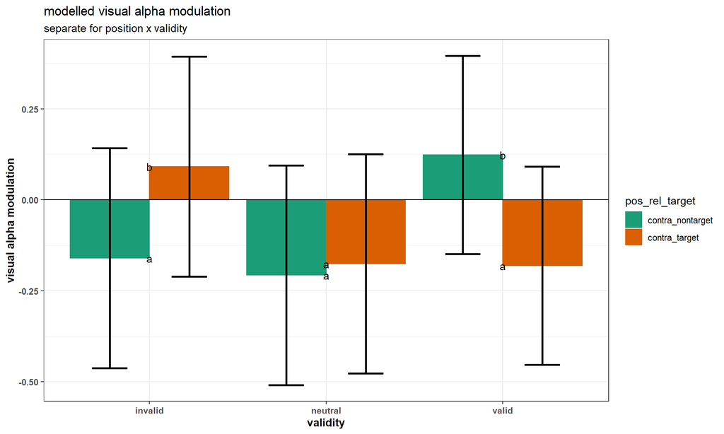

```r
CLD_obj = cld(anova_lsmeans_c,
          alpha=0.05,
          Letters=letters,      ### Use lower-case letters for .group
          adjust="holm")
CLD_obj$.group=gsub(" ", "", CLD_obj$.group)

ggplot(CLD_obj, aes(x = cue_validity_label, y = lsmean, color = pos_rel_target, fill = pos_rel_target, label = .group)) +
  stat_summary(fun.data = mean_se, geom = "bar", position = "dodge") +
  geom_hline(yintercept=0, show.legend = FALSE) +
  geom_errorbar(aes(ymin = asymp.LCL, ymax = asymp.UCL), width=.4, size=.9, position = position_dodge(0.9),color = "black") +
  theme_bw() +
  theme(axis.title = element_text(face = "bold"), axis.text = element_text(face = "bold"),plot.caption = element_text(hjust = 0)) +
  ylab("visual alpha modulation") +
  ggtitle("modelled visual alpha modulation",
           subtitle="separate for position x validity") +
  scale_x_discrete("validity") +
  # labs(caption  = paste0("\nMeans sharing a letter are ",
  #                        "not significantly different.",
  #                        "(holm corrected comparisons)."), hjust=0.5) +
  geom_text(nudge_x = c(-0.05 +0.05), color   = "black") +
  scale_fill_brewer(palette = "Dark2")+
  scale_color_brewer(palette = "Dark2")
```

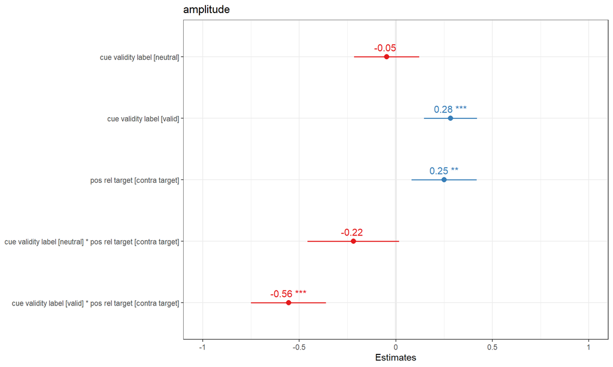

```r
plot_model(model2test, bpe.style = "dot",show.values = TRUE)
```

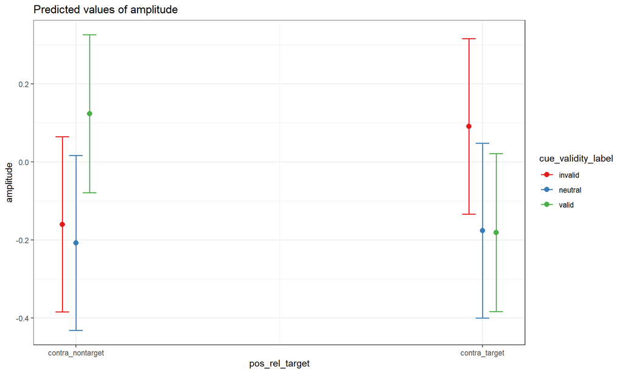

```r
plot_model(model2test, type = "pred", terms = c("pos_rel_target","cue_validity_label"))
```

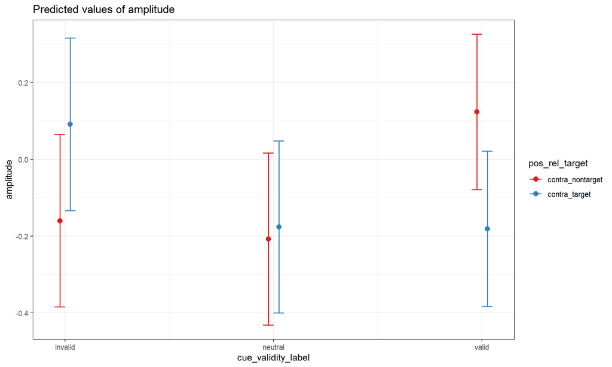

```r
plot_model(model2test, type = "pred", terms = c("cue_validity_label","pos_rel_target"))
```

### linear mixed models motor alpha II

1. **estimating model**

linear mixed model of standard effects based on single trial data

testing **motor alpha ~ Validity * Stimulus + ( 1 | subjects)**

motor Alpha | fixed effects | stepwise elimination

|  | eliminated factor | Eliminated | Sum Sq | Mean Sq | NumDF | DenDF | F value | Pr(>F) |
| --- | --- | --- | --- | --- | --- | --- | --- | --- |
| cue_validity_label:pos_rel_target | cue_validity_label:pos_rel_target | 0 | 590.664 | 295.332 | 2 | 20623.4 | 32.187 | < .001 |

2. model description of best model
   - Best model is lmerTest::lmer, amplitude ~ cue_validity_label * pos_rel_target + (1 | subject), lmer_model_data, TRUE

```r
model2test = best_model

## validity
anova_lsmeans_c <- lsmeans(model2test, c("cue_validity_label"))
```

```
## Note: D.f. calculations have been disabled because the number of observations exceeds 3000.
## To enable adjustments, add the argument 'pbkrtest.limit = 20656' (or larger)
## [or, globally, 'set emm_options(pbkrtest.limit = 20656)' or larger];
## but be warned that this may result in large computation time and memory use.
```

```
## Note: D.f. calculations have been disabled because the number of observations exceeds 3000.
## To enable adjustments, add the argument 'lmerTest.limit = 20656' (or larger)
## [or, globally, 'set emm_options(lmerTest.limit = 20656)' or larger];
## but be warned that this may result in large computation time and memory use.
```

```
## NOTE: Results may be misleading due to involvement in interactions
```

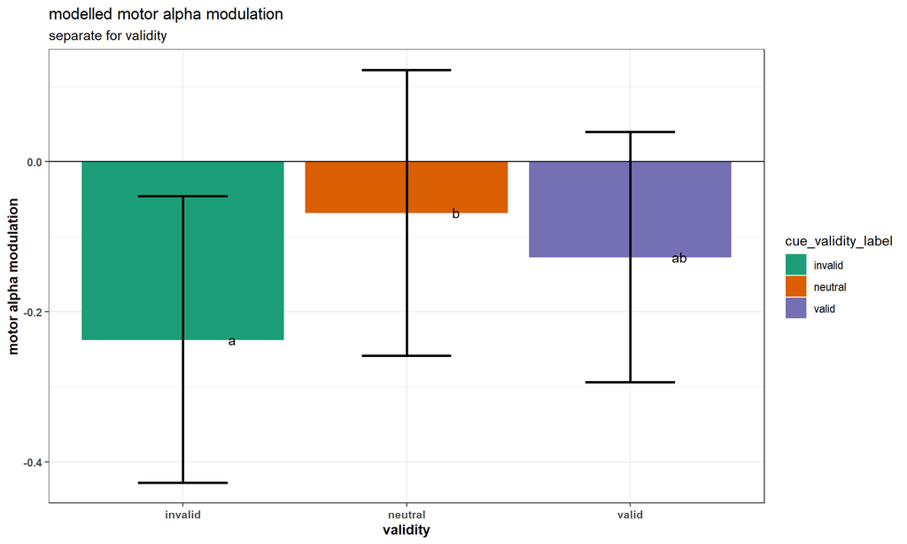

```r
CLD_obj = cld(anova_lsmeans_c,
          alpha=0.05,
          Letters=letters,      ### Use lower-case letters for .group
          adjust="holm")
CLD_obj$.group=gsub(" ", "", CLD_obj$.group)

ggplot(CLD_obj, aes(x = cue_validity_label , y = lsmean, color = cue_validity_label , fill = cue_validity_label , label = .group)) +
  stat_summary(fun.data = mean_se, geom = "bar", position = "dodge") +
  geom_hline(yintercept=0, show.legend = FALSE) +
  geom_errorbar(aes(ymin = asymp.LCL, ymax = asymp.UCL), width=.4, size=.9, position = position_dodge(0.4),color = "black") +
  theme_bw() +
  theme(axis.title = element_text(face = "bold"), axis.text = element_text(face = "bold"),plot.caption = element_text(hjust = 0)) +
  ylab("motor alpha modulation") +
  ggtitle("modelled motor alpha modulation",
           subtitle="separate for validity") +
  scale_x_discrete("validity") +
  # ggplot2::labs(caption  = paste0("\nMeans sharing a letter are ",
  #                        "not significantly different.",
  #                        "(holm corrected comparisons).")), hjust=0.5) +
  geom_text(nudge_x = c(+0.22), color   = "black") +
  scale_fill_brewer(palette = "Dark2")+
  scale_color_brewer(palette = "Dark2")
```

```r
## position
anova_lsmeans_c <- lsmeans(model2test, c("pos_rel_target"))
```

```
## Note: D.f. calculations have been disabled because the number of observations exceeds 3000.
## To enable adjustments, add the argument 'pbkrtest.limit = 20656' (or larger)
## [or, globally, 'set emm_options(pbkrtest.limit = 20656)' or larger];
## but be warned that this may result in large computation time and memory use.
```

```
## Note: D.f. calculations have been disabled because the number of observations exceeds 3000.
## To enable adjustments, add the argument 'lmerTest.limit = 20656' (or larger)
## [or, globally, 'set emm_options(lmerTest.limit = 20656)' or larger];
## but be warned that this may result in large computation time and memory use.
```

```
## NOTE: Results may be misleading due to involvement in interactions
```

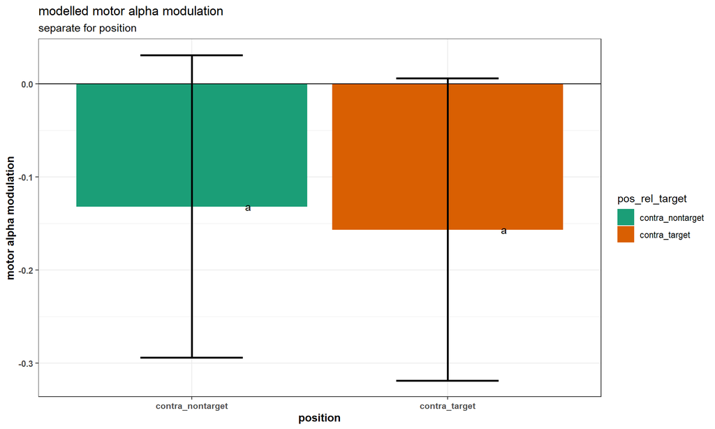

```r
CLD_obj = cld(anova_lsmeans_c,
          alpha=0.05,
          Letters=letters,      ### Use lower-case letters for .group
          adjust="holm")
CLD_obj$.group=gsub(" ", "", CLD_obj$.group)

ggplot(CLD_obj, aes(x = pos_rel_target, y = lsmean, color = pos_rel_target, fill = pos_rel_target, label = .group)) +
  stat_summary(fun.data = mean_se, geom = "bar", position = "dodge") +
  geom_hline(yintercept=0, show.legend = FALSE) +
  geom_errorbar(aes(ymin = asymp.LCL, ymax = asymp.UCL), width=.4, size=.9, position = position_dodge(0.4),color = "black") +
  theme_bw() +
  theme(axis.title = element_text(face = "bold"), axis.text = element_text(face = "bold"),plot.caption = element_text(hjust = 0)) +
  ylab("motor alpha modulation") +
  ggtitle("modelled motor alpha modulation",
           subtitle="separate for position") +
  scale_x_discrete("position") +
  # labs(caption  = paste0("\nMeans sharing a letter are ",
  #                        "not significantly different.",
  #                        "(holm corrected comparisons)."), hjust=0.5) +
  geom_text(nudge_x = c(+0.22), color   = "black") +
  scale_fill_brewer(palette = "Dark2")+
  scale_color_brewer(palette = "Dark2")
```

```r
## Validiaet X Seite
anova_lsmeans_c <- lsmeans(model2test, c("pos_rel_target","cue_validity_label"))
```

```
## Note: D.f. calculations have been disabled because the number of observations exceeds 3000.
## To enable adjustments, add the argument 'pbkrtest.limit = 20656' (or larger)
## [or, globally, 'set emm_options(pbkrtest.limit = 20656)' or larger];
## but be warned that this may result in large computation time and memory use.
```

```
## Note: D.f. calculations have been disabled because the number of observations exceeds 3000.
## To enable adjustments, add the argument 'lmerTest.limit = 20656' (or larger)
## [or, globally, 'set emm_options(lmerTest.limit = 20656)' or larger];
## but be warned that this may result in large computation time and memory use.
```

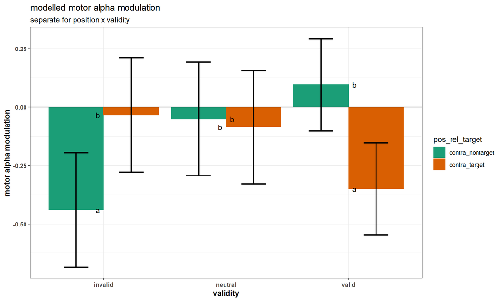

```r
CLD_obj = cld(anova_lsmeans_c,
          alpha=0.05,
          Letters=letters,      ### Use lower-case letters for .group
          adjust="holm")
CLD_obj$.group=gsub(" ", "", CLD_obj$.group)

ggplot(CLD_obj, aes(x = cue_validity_label, y = lsmean, color = pos_rel_target, fill = pos_rel_target, label = .group)) +
  stat_summary(fun.data = mean_se, geom = "bar", position = "dodge") +
  geom_hline(yintercept=0, show.legend = FALSE) +
  geom_errorbar(aes(ymin = asymp.LCL, ymax = asymp.UCL), width=.4, size=.9, position = position_dodge(0.9),color = "black") +
  theme_bw() +
  theme(axis.title = element_text(face = "bold"), axis.text = element_text(face = "bold"),plot.caption = element_text(hjust = 0)) +
  ylab("motor alpha modulation") +
  ggtitle("modelled motor alpha modulation",
           subtitle="separate for position x validity") +
  scale_x_discrete("validity") +
  # labs(caption  = paste0("\nMeans sharing a letter are ",
  #                        "not significantly different.",
  #                        "(holm corrected comparisons)."), hjust=0.5) +
  geom_text(nudge_x = c(-0.05, +0.05), color   = "black") +
  scale_fill_brewer(palette = "Dark2")+
  scale_color_brewer(palette = "Dark2")
```

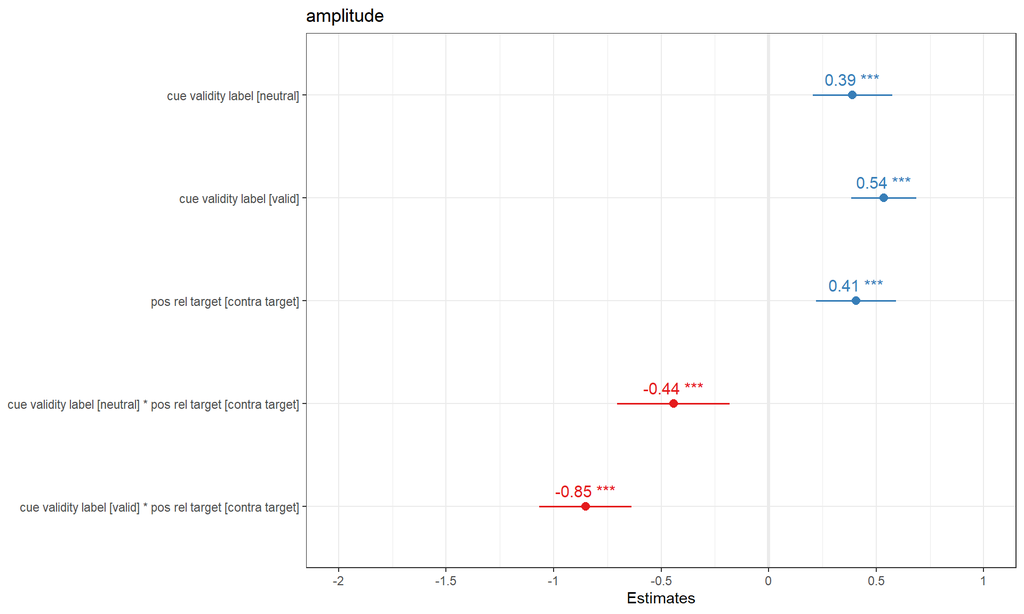

```r
plot_model(model2test, bpe.style = "dot",show.values = TRUE)
```

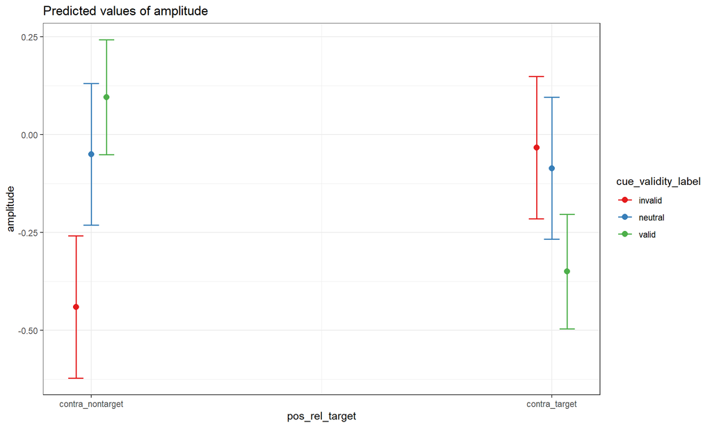

```r
plot_model(model2test, type = "pred", terms = c("pos_rel_target","cue_validity_label"))
```

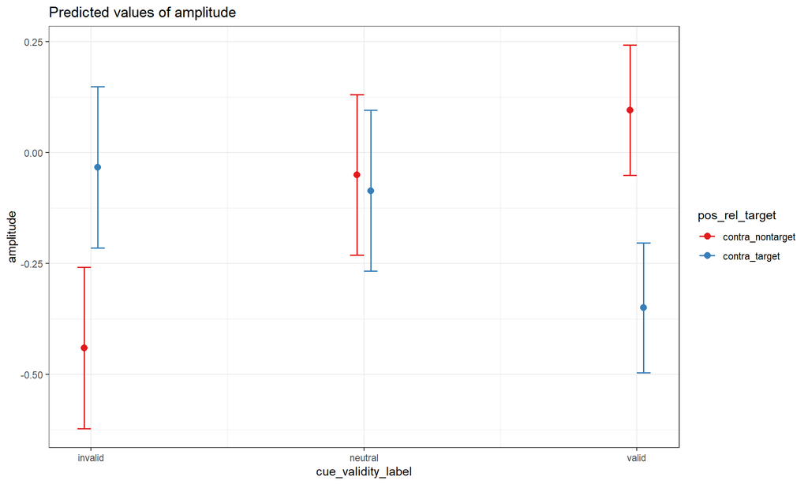

```r
plot_model(model2test, type = "pred", terms = c("cue_validity_label","pos_rel_target"))
```